# ANA 515 - Assignment 4 Data Analytics Project

## Section 7 and 8: Produce output and visuals

```r
# Plotting the trips by the hours in a day

# Table of hours and trips
hour_data <- data_2014 %>%
           group_by(hour) %>%
               dplyr::summarize(Total = n())
datatable(hour_data)
```

|  | hour | Total |
| --- | --- | --- |
| 1 | 0 | 103836 |
| 2 | 1 | 67227 |
| 3 | 2 | 45865 |
| 4 | 3 | 48287 |
| 5 | 4 | 55230 |
| 6 | 5 | 83939 |
| 7 | 6 | 143213 |
| 8 | 7 | 193094 |
| 9 | 8 | 190504 |
| 10 | 9 | 159967 |

[output cut: 14 more lines]

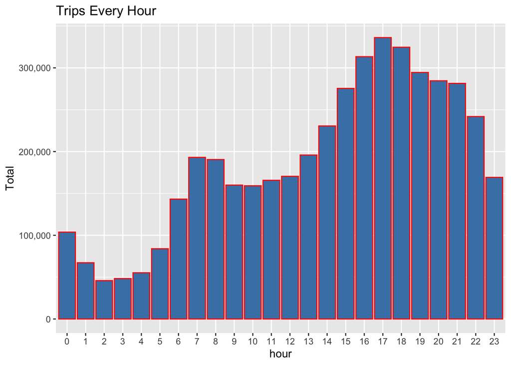

```r
# ggplot
ggplot(hour_data, aes(hour, Total)) +
        geom_bar( stat = "identity", fill = "steelblue", color = "red") +
           ggtitle("Trips Every Hour") +
            theme(legend.position = "none") +
            scale_y_continuous(labels = comma)
```

```r
month_hour <- data_2014 %>%
          group_by(month, hour) %>%
             dplyr::summarize(Total = n())
```

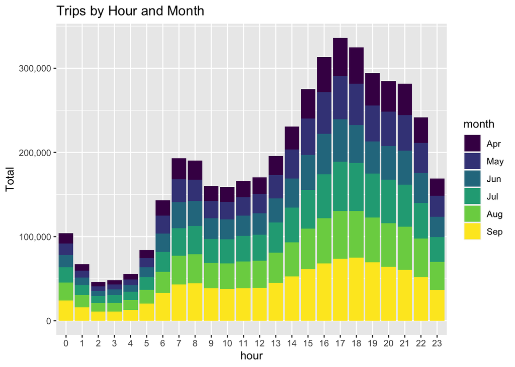

```r
ggplot(month_hour, aes(hour, Total, fill = month)) +
       geom_bar( stat = "identity") +
          ggtitle("Trips by Hour and Month") +
           scale_y_continuous(labels = comma)
```

```r
# Plotting data by trips during every day of the month

day_group <- data_2014 %>%
          group_by(day) %>%
             dplyr::summarize(Total = n())
datatable(day_group)
```

|  | day | Total |
| --- | --- | --- |
| 1 | 1 | 127430 |
| 2 | 2 | 143201 |
| 3 | 3 | 142983 |
| 4 | 4 | 140923 |
| 5 | 5 | 147054 |
| 6 | 6 | 139886 |
| 7 | 7 | 143503 |
| 8 | 8 | 145984 |
| 9 | 9 | 155135 |
| 10 | 10 | 152500 |

[output cut: 21 more lines]

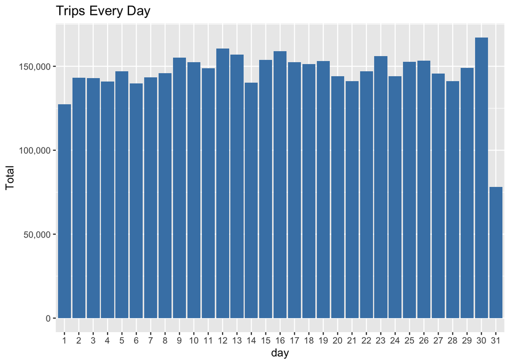

```r
# what's in here?

ggplot(day_group, aes(day, Total)) +
        geom_bar( stat = "identity", fill = "steelblue") +
           ggtitle("Trips Every Day") +
            theme(legend.position = "none") +
            scale_y_continuous(labels = comma)
```

```r
# Number of Trips taking place during months in a year

month_group <- data_2014 %>%
          group_by(month) %>%
             dplyr::summarize(Total = n())
datatable(month_group)
```

|  | month | Total |
| --- | --- | --- |
| 1 | Apr | 564516 |
| 2 | May | 652435 |
| 3 | Jun | 663844 |
| 4 | Jul | 796121 |
| 5 | Aug | 829275 |
| 6 | Sep | 1028136 |

```r
# Creating a Heatmap visualization of day, hour and month

#table
day_and_hour <- data_2014 %>%
         group_by(day, hour) %>%
            dplyr::summarize(Total = n())
```

[output not shown]

```r
datatable(day_and_hour)
```

|  | day | hour | Total |
| --- | --- | --- | --- |
| 1 | 1 | 0 | 3247 |
| 2 | 1 | 1 | 1982 |
| 3 | 1 | 2 | 1284 |
| 4 | 1 | 3 | 1331 |
| 5 | 1 | 4 | 1458 |
| 6 | 1 | 5 | 2171 |
| 7 | 1 | 6 | 3717 |
| 8 | 1 | 7 | 5470 |
| 9 | 1 | 8 | 5376 |
| 10 | 1 | 9 | 4688 |

[output cut: 734 more lines]

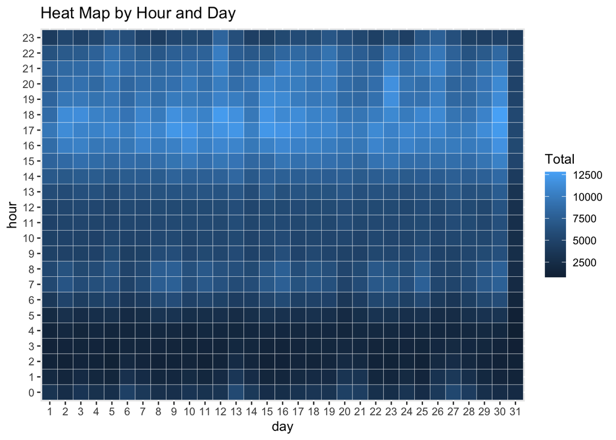

```r
#Heatmap
ggplot(day_and_hour, aes(day, hour, fill = Total)) +
            geom_tile(color = "white") +
              ggtitle("Heat Map by Hour and Day")
```

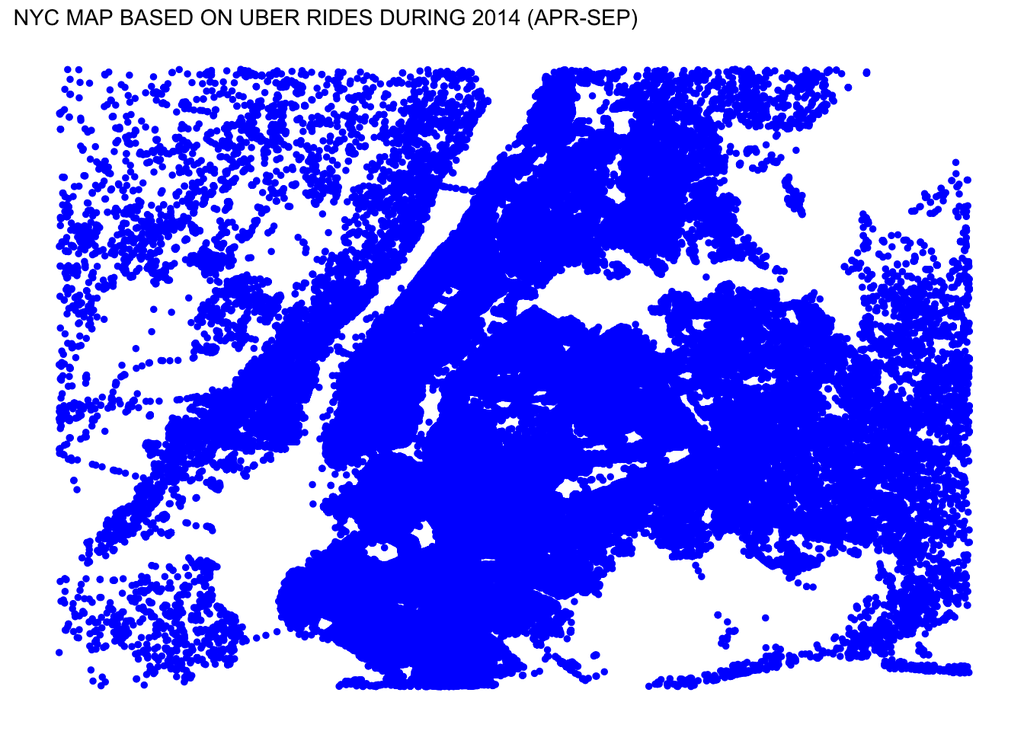

```r
# visualize the rides in New York city by creating a geo-plot that will help us to visualize the rides during 2014 (Apr – Sep) and by the bases in the same period.

min_lat <- 40.5774
max_lat <- 40.9176
min_long <- -74.15
max_long <- -73.7004
ggplot(data_2014, aes(x=Lon, y=Lat)) +
  geom_point(size=1, color = "blue") +
     scale_x_continuous(limits=c(min_long, max_long)) +
      scale_y_continuous(limits=c(min_lat, max_lat)) +
        theme_map() +
           ggtitle("NYC MAP BASED ON UBER RIDES DURING 2014 (APR-SEP)")
```

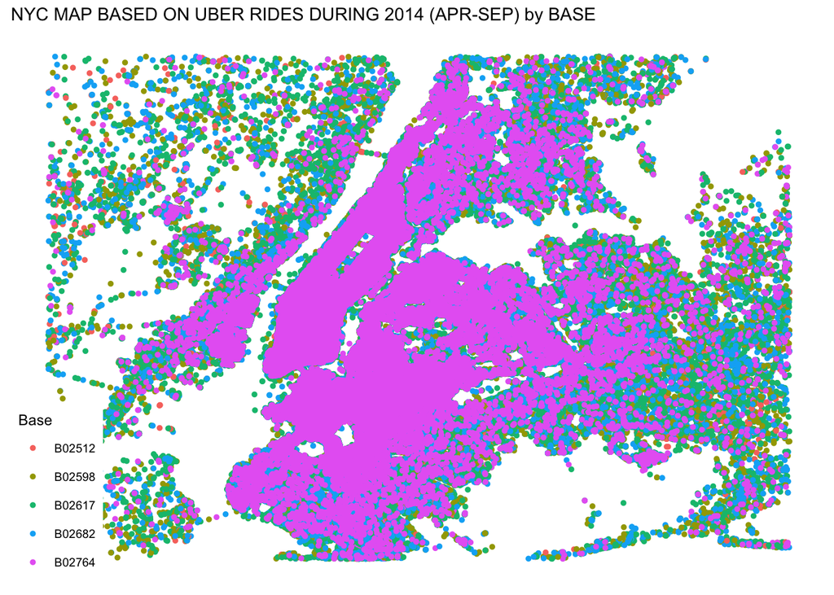

```r
ggplot(data_2014, aes(x=Lon, y=Lat, color = Base)) +
  geom_point(size=1) +
     scale_x_continuous(limits=c(min_long, max_long)) +
      scale_y_continuous(limits=c(min_lat, max_lat)) +
       theme_map() +
          ggtitle("NYC MAP BASED ON UBER RIDES DURING 2014 (APR-SEP) by BASE")
```

## Section 9: Your document should clearly and concisely communicate the project

In this Uber data analysis R project, they observed how to create data visualizations and used several packages such as ggplot2 to plot various types of visualizations that pertained to several time-frames of the year. That allowed them to conclude how time affected customer trips in Uber. Finally, the geo plot of New York that provided the details of how various users made trips from different base points.